# SHAP

Author

Luying Shu

rpackage fastshap https://github.com/bgreenwell/fastshap

```r
library("fastshap")
library(gower)
library(cluster)
library(tidyverse)
library(randomForest)
```

```r
set.seed(5293)
mushrooms <- read.csv("D:/Desktop/interpretable ml/Pset1/mushrooms.csv", stringsAsFactors = TRUE)
head(mushrooms)
```

```
       type cap_shape cap_surface cap_color bruises    odor gill_attachment
1 poisonous    convex      smooth     brown     yes pungent            free
2    edible    convex      smooth    yellow     yes  almond            free
3    edible      bell      smooth     white     yes   anise            free
4 poisonous    convex       scaly     white     yes pungent            free
5    edible    convex      smooth      gray      no    none            free
6    edible    convex       scaly    yellow     yes  almond            free
  gill_spacing gill_size gill_color stalk_shape stalk_root
1        close    narrow      black   enlarging      equal
2        close     broad      black   enlarging       club
3        close     broad      brown   enlarging       club
4        close    narrow      brown   enlarging      equal
5      crowded     broad      black    tapering      equal
6        close     broad      brown   enlarging       club
  stalk_surface_above_ring stalk_surface_below_ring stalk_color_above_ring
```

[output cut: 20 more lines]

```r
n <- nrow(mushrooms)
test_index <- sample(n, 1)
train_dat <- mushrooms[-test_index, ]
test_dat <- mushrooms[test_index, ]
library(lime)
mod <- randomForest(type ~ ., data = mushrooms)
mod
```

```
Call:
 randomForest(formula = type ~ ., data = mushrooms)
               Type of random forest: classification
                     Number of trees: 500
No. of variables tried at each split: 4

        OOB estimate of  error rate: 0%
Confusion matrix:
          edible poisonous class.error
edible      4208         0           0
poisonous      0      3916           0
```

```r
predict(mod, newdata=  test_dat)
```

```
  2885
edible
Levels: edible poisonous
```

```r
pred = function(model, newdata){
  predict(model, newdata = newdata, type = "prob")[,'poisonous']
}

shap_values = fastshap::explain(
  mod,
  X = train_dat,
  feature_names = colnames(train_dat)[2:23],
  pred_wrapper = pred,
  nsim = 500,
  newdata = test_dat,
  adjust = TRUE
)
```

```r
library(tidyverse)

df = shap_values|>
  data.frame()|>
  pivot_longer(cols = everything(),
               names_to = "variable")|>
  mutate(value = abs(value))|>
  group_by(variable)|>
  summarize(mean = mean(value))|>
  arrange(desc(mean))

df
```

```
# A tibble: 22 × 2
   variable                   mean
   <chr>                     <dbl>
 1 odor                     0.190
 2 spore_print_color        0.0920
 3 gill_color               0.0372
 4 stalk_surface_above_ring 0.0351
 5 ring_type                0.0348
 6 gill_size                0.0333
 7 bruises                  0.0198
 8 stalk_surface_below_ring 0.0169
 9 stalk_shape              0.0153
10 population               0.0104
# ℹ 12 more rows
```

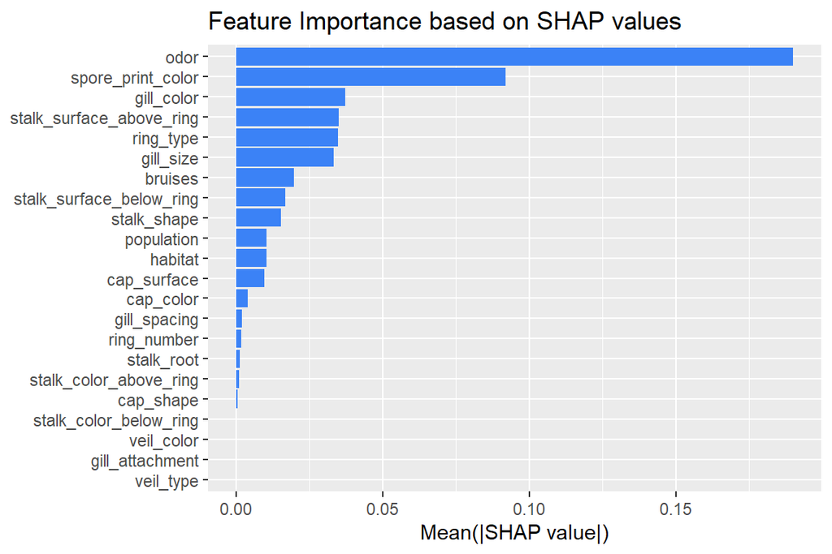

```r
ggplot(df, aes(x = reorder(variable, mean), y = mean)) +
  geom_col(fill = "#3B82F6") +
  coord_flip() +
  labs(
    x = NULL,
    y = "Mean(|SHAP value|)",
    title = "Feature Importance based on SHAP values")
```

```r
# Minimal runnable SHAP computation function (single sample)
# model: trained model
# X: training data (excluding the target variable)
# x: single sample to explain (data frame with same column names as X)
# pred_fun: a function that takes (model, newdata) and returns predicted values (numeric vector)
# nsim: number of sampling iterations

simple_shap <- function(model, X, x, pred_fun, nsim = 50) {
  p <- ncol(X)
  shap_values <- numeric(p)
  names(shap_values) <- colnames(X)

  for (sim in 1:nsim) {
    perm <- sample(p)  # random feature order
    S <- c()           # set of features already included

    for (j in perm) {
      # Construct cases S and S ∪ {j}
      X_S <- X
      X_Sj <- X

      # For features outside S, replace with the value from sample x (simulate known/unknown features)
      for (col in setdiff(1:p, S)) {
        X_S[, col] <- x[[col]]
      }
      for (col in setdiff(1:p, c(S, j))) {
        X_Sj[, col] <- x[[col]]
      }

      # Prediction
      pred_S  <- mean(pred_fun(model, X_S))
      pred_Sj <- mean(pred_fun(model, X_Sj))

      shap_values[j] <- shap_values[j] + (pred_Sj - pred_S)
      S <- c(S, j)
    }
  }

  shap_values / nsim
}
```

```r
pred_fun <- function(model, newdata) {
  predict(model, newdata, type = "prob")[, "poisonous"]
}

# use simple_shap to calculate SHAP
my_shap_values <- simple_shap(
  model = mod,
  X = train_dat[ , -1],
  x = test_dat[ , -1],
  pred_fun = pred_fun,
  nsim = 10
)

df_my <- my_shap_values |>
  t() |>
  data.frame() |>
  pivot_longer(cols = everything(),
               names_to = "variable") |>
  mutate(value = abs(value)) |>
  group_by(variable) |>
  summarize(mean = mean(value)) |>
  arrange(desc(mean))

# fastshap result
df_fast <- shap_values |>
  data.frame() |>
  pivot_longer(cols = everything(),
               names_to = "variable") |>
  mutate(value = abs(value)) |>
  group_by(variable) |>
  summarize(mean = mean(value)) |>
  arrange(desc(mean))

comparison <- left_join(df_fast, df_my, by = "variable", suffix = c("_fastshap", "_simple"))
print(comparison)
```

```
# A tibble: 22 × 3
   variable                 mean_fastshap mean_simple
   <chr>                            <dbl>       <dbl>
 1 odor                            0.190      0.204
 2 spore_print_color               0.0920     0.0867
 3 gill_color                      0.0372     0.0378
 4 stalk_surface_above_ring        0.0351     0.0234
 5 ring_type                       0.0348     0.0370
 6 gill_size                       0.0333     0.0350
 7 bruises                         0.0198     0.0160
 8 stalk_surface_below_ring        0.0169     0.0115
 9 stalk_shape                     0.0153     0.0175
10 population                      0.0104     0.00860
# ℹ 12 more rows
```

```r
# Minimal MC-SHAP aligned with fastshap semantics (multi-row x)
# model: trained model
# X: background data (features only; data.frame or matrix)
# x: observations to explain (same columns as X; can have multiple rows)
# pred_fun(model, newdata) -> numeric vector (prob or reg)
# nsim: Monte Carlo repetitions
# adjust: enforce local accuracy sum(phi) == f(x) - baseline (approx.)
# baseline: NULL -> mean(pred(X)); numeric -> use it

simple_shap <- function(model, X, x, pred_fun, nsim = 50,
                        adjust = TRUE, baseline = NULL) {
  stopifnot(is.data.frame(X) || is.matrix(X))
  stopifnot(is.data.frame(x) || is.matrix(x))
  if (!identical(colnames(X), colnames(x))) {
    stop("Columns of `x` must match `X` (same names and order).")
  }

  X <- if (inherits(X, "tbl_df")) as.data.frame(X) else X
  x <- if (inherits(x, "tbl_df")) as.data.frame(x) else x

  n_bg <- nrow(X)
  p    <- ncol(X)
  m    <- nrow(x)
  cols <- colnames(X)

  # baseline and f(x)
  fnull <- if (is.null(baseline)) mean(pred_fun(model, X)) else baseline
  fx    <- as.numeric(pred_fun(model, x))  # length m

  # result matrix: m rows (obs), p cols (features)
  phis  <- matrix(0, nrow = m, ncol = p, dimnames = list(NULL, cols))

  for (i in seq_len(m)) {
    xi <- x[i, , drop = FALSE]

    # accumulate over nsim permutations
    phi_i <- numeric(p)

    for (sim in seq_len(nsim)) {
      perm <- sample.int(p)   # random feature order
      Sidx <- integer(0)

      # bootstrap background W (with replacement)
      idx <- sample.int(n_bg, n_bg, replace = TRUE)
      W   <- X[idx, , drop = FALSE]

      for (j in perm) {
        # World S: known features S take value x_i; others from W
        B_S  <- W
        if (length(Sidx)) {
          for (cc in Sidx) {
            B_S[, cc] <- rep(xi[[cc]], nrow(B_S))
          }
        }

        # World S∪{j}: add feature j as known (value from x_i)
        B_Sj <- B_S
        B_Sj[, j] <- rep(xi[[j]], nrow(B_Sj))

        # expected predictions under the two worlds
        pred_S  <- mean(pred_fun(model, B_S))
        pred_Sj <- mean(pred_fun(model, B_Sj))

        # marginal contribution of feature j for this permutation
        phi_i[j] <- phi_i[j] + (pred_Sj - pred_S)

        # grow coalition S
        Sidx <- c(Sidx, j)
      }
    }

    # average over nsim
    phi_i <- phi_i / nsim

    # optional local accuracy adjustment (simple proportional shift)
    if (isTRUE(adjust)) {
      err <- (fx[i] - fnull) - sum(phi_i)
      w <- abs(phi_i)
      if (sum(w) == 0) {
        # if all zeros, distribute equally
        phi_i <- phi_i + err / p
      } else {
        phi_i <- phi_i + err * (w / sum(w))
      }
    }

    phis[i, ] <- phi_i
  }

  attr(phis, "baseline") <- fnull
  attr(phis, "fx") <- fx
  class(phis) <- c("explain", class(phis))
  phis
}
```

```r
pred_fun <- function(model, newdata) {
  predict(model, newdata, type = "prob")[, "poisonous"]
}

# use simple_shap to calculate SHAP
my_shap_values <- simple_shap(
  model = mod,
  X = train_dat[ , -1],
  x = test_dat[ , -1],
  pred_fun = pred_fun,
  nsim = 10
)

df_my <- my_shap_values |>
  as.data.frame() |>
  tidyr::pivot_longer(cols = dplyr::everything(),
                      names_to = "variable", values_to = "value") |>
  dplyr::mutate(value = abs(value)) |>
  dplyr::group_by(variable) |>
  dplyr::summarise(mean_simple = mean(value, na.rm = TRUE), .groups = "drop") |>
  dplyr::arrange(dplyr::desc(mean_simple))

df_fast <- shap_values |>
  as.data.frame() |>
  tidyr::pivot_longer(cols = dplyr::everything(),
                      names_to = "variable", values_to = "value") |>
  dplyr::mutate(value = abs(value)) |>
  dplyr::group_by(variable) |>
  dplyr::summarise(mean_fastshap = mean(value, na.rm = TRUE), .groups = "drop") |>
  dplyr::arrange(dplyr::desc(mean_fastshap))

comparison <- dplyr::left_join(df_fast, df_my, by = "variable")
print(comparison)
```

```
# A tibble: 22 × 3
   variable                 mean_fastshap mean_simple
   <chr>                            <dbl>       <dbl>
 1 odor                            0.190      0.176
 2 spore_print_color               0.0920     0.0817
 3 gill_color                      0.0372     0.0399
 4 stalk_surface_above_ring        0.0351     0.0408
 5 ring_type                       0.0348     0.0372
 6 gill_size                       0.0333     0.0363
 7 bruises                         0.0198     0.0244
 8 stalk_surface_below_ring        0.0169     0.0180
 9 stalk_shape                     0.0153     0.0153
10 population                      0.0104     0.00870
# ℹ 12 more rows
```

# Algorithm & Math for `simple_shap` (RMarkdown)

## Overview

This function estimates **Shapley values** for one or more observations using the **Monte Carlo (MC) permutation** approach of Štrumbelj & Kononenko (2014), aligned with the semantics used in `fastshap`. For each observation $x$, we average the **marginal contribution** of each feature across many random feature orderings, with **background resampling** to approximate expectations. An optional **local accuracy adjustment** shifts the Shapley values so that they sum (approximately) to $f(x) - \text{baseline}$.

## Notation

- $f(\cdot)$: the trained predictive model (wrapped by `pred_fun`).
- $X \in \mathbb{R}^{n_{\text{bg}} \times p}$: **background** feature dataset (no target column).
- $x \in \mathbb{R}^{1 \times p}$: a **single observation** to explain; for multiple rows, $x_i$ denotes the $i$-th row.
- $p$: number of features; feature set $\mathcal{P} = \{1,\dots,p\}$.
- $\pi$: a random **permutation** of the features.
- $S \subseteq \mathcal{P}$: the set of features that **precede** a given feature $j$ in $\pi$.
- $W$: a **bootstrap sample** (with replacement) of rows from $X$, used to approximate conditional expectations when features are “unknown”.
- $B_S$, $B_{S \cup \{j\}}$: “Frankenstein” datasets where **known** features are set to $x$’s values and **unknown** features are taken from $W$.
- $n_{\text{sim}}$ (code: `nsim`): number of MC permutations.

## Goal: Shapley Values for Local Explanation

For a single observation $x$, the **Shapley value** $\phi_j(x)$ for feature $j$ is the average **marginal contribution** of $j$ over all permutations:

$$\phi_j(x) \;=\; \mathbb{E}_{\pi}\Big[\, f\big(x_{S \cup \{j\}}\big) \;-\; f\big(x_{S}\big)\,\Big],$$

where $S = \{k \in \mathcal{P} : k \text{ precedes } j \text{ in } \pi\}$. Here, $x_S$ denotes the **hybrid input** formed by fixing features in $S$ to their values in $x$ and “integrating out” the others.

In practice, the **expectation over unknown features** is approximated with a bootstrap background:

$$f(x_{S}) \;\approx\; \frac{1}{|W|} \sum_{w \in W} f\!\big( \text{Hybrid}(w; x, S) \big),$$

and similarly for $x_{S \cup \{j\}}$.

## Hybrid (“Frankenstein”) Construction

For a given coalition $S$ and a background row $w \in W$, define

$$\text{Hybrid}(w; x, S)_k \;=\;
\begin{cases}
x_k, & \text{if } k \in S,\\
w_k, & \text{if } k \notin S.
\end{cases}$$

Then build the **two worlds** for the marginal of feature $j$:

- **World $S$:** known $S$ take $x$’s values; others from $W$.
- **World $S \cup \{j\}$:** same as $S$, plus feature $j$ set to $x_j$.

Their **expected predictions** are approximated by averaging model outputs over all rows of $W$:

$$\widehat{\mathbb{E}}\!\left[f(\cdot \mid S)\right] \;=\; \frac{1}{|W|}\sum_{w \in W} f\!\big(\text{Hybrid}(w; x, S)\big),\quad
\widehat{\mathbb{E}}\!\left[f(\cdot \mid S\cup\{j\})\right] \;=\; \frac{1}{|W|}\sum_{w \in W} f\!\big(\text{Hybrid}(w; x, S\cup\{j\})\big).$$

The **marginal contribution** in one permutation is

$$\Delta_{j,\pi}(x) \;=\;
\widehat{\mathbb{E}}\!\left[f(\cdot \mid S\cup\{j\})\right] \;-\;
\widehat{\mathbb{E}}\!\left[f(\cdot \mid S)\right].$$

## Monte Carlo Estimator

Repeat over $n_{\text{sim}}$ random permutations $\pi^{(1)},\dots,\pi^{(n_{\text{sim}})}$, each with an independently bootstrapped background $W^{(s)}$. The MC estimator is:

$$\widehat{\phi}_j(x) \;=\; \frac{1}{n_{\text{sim}}} \sum_{s=1}^{n_{\text{sim}}} \Delta_{j,\pi^{(s)}}(x).$$

For **multiple observations** $x_1,\dots,x_m$, assemble into a matrix

$$\Phi \in \mathbb{R}^{m \times p},\quad
\Phi_{i,j} \;=\; \widehat{\phi}_j(x_i).$$

## Baseline and Local Accuracy

- The function computes a **baseline**:

$$\text{baseline} \;=\; f_{\emptyset} \;\equiv\; \frac{1}{|X|}\sum_{x' \in X} f(x'),$$

denoted as $\,f_{\text{null}}$ (code: `fnull`).

- The **local accuracy** (a.k.a. additivity) desirable property is

$$\sum_{j=1}^p \phi_j(x) \;=\; f(x) \;-\; f_{\text{null}}.$$

Because MC estimates can drift, we apply a **post-hoc adjustment**:

$$\text{err}(x) \;=\; \big(f(x) - f_{\text{null}}\big) \;-\; \sum_{j=1}^p \widehat{\phi}_j(x).$$

With nonnegative weights $w_j(x)$ (here $w_j = |\widehat{\phi}_j|$ as a simple heuristic), set

$$\widehat{\phi}_j^{\,\text{adj}}(x)
\;=\; \widehat{\phi}_j(x) \;+\; \text{err}(x)\,\frac{w_j(x)}{\sum_{k=1}^p w_k(x)}.$$

This preserves **relative magnitudes** and enforces $\sum_j \widehat{\phi}_j^{\,\text{adj}}(x) = f(x) - f_{\text{null}}$ (up to numerical error).

## End-to-End Flow (What the Function Does)

1. **Inputs & checks** Ensure $X$ and $x$ share the same columns/orders; coerce tibbles to data frames.
2. **Compute $f(x)$ and baseline**

   $$f(x_i) \leftarrow \text{pred\_fun}(model, x_i),\quad
   f_{\text{null}} \leftarrow \frac{1}{|X|}\sum f(X).$$
3. **Initialize storage** $\Phi \gets \mathbf{0}_{m \times p}$.
4. **Loop over each row $x_i$** For $i=1,\dots,m$:
   - Initialize $\phi_i \gets \mathbf{0}_p$.
   - For $s=1,\dots,n_{\text{sim}}$:
     - Sample a permutation $\pi^{(s)}$.
     - Bootstrap background $W^{(s)}$ from $X$（有放回）.
     - Grow coalition $S$ along $\pi^{(s)}$. For each $j \in \pi^{(s)}$:
       - Build $B_S$ and $B_{S\cup\{j\}}$ (known $S$ use $x_i$’s values; unknown from $W^{(s)}$).
       - Compute $\Delta_{j,\pi^{(s)}}(x_i)$ as averaged prediction difference.
       - Accumulate $\phi_i[j] \mathrel{+}= \Delta_{j,\pi^{(s)}}(x_i)$.
   - Average: $\phi_i \leftarrow \phi_i / n_{\text{sim}}$.
   - **Optional local accuracy adjust**:

     $$\phi_i \leftarrow \phi_i + \text{err}(x_i)\,\frac{w(\phi_i)}{\sum w(\phi_i)}.$$
   - Set $\Phi_{i,\cdot} \leftarrow \phi_i$.
5. **Return $\Phi$** with attributes Attach `baseline = fnull`, `fx = f(x)`; set class for downstream plotting.

## Classification vs. Regression

- **Regression:** $f(\cdot)$ returns numeric predictions.
- **Binary classification:** $f(\cdot)$ returns the **probability** for the reference class (e.g., $P(Y=\text{“poisonous”}\mid X)$). The formulation above applies identically; only the interpretation of $f$ changes.

## Practical Considerations

- **Stability:** Increase $n_{\text{sim}}$ to reduce MC variance.
- **Background choice:** $X$ should represent the data distribution you regard as the reference (often training data).
- **Complexity:** Roughly $O\!\big(m \cdot n_{\text{sim}} \cdot p \cdot C_{\text{pred}}\big)$, where $C_{\text{pred}}$ is the average cost to predict on two Frankenstein batches (each of size $|W|$).
- **Adjustment weights:** This implementation uses $w_j = |\widehat{\phi}_j|$ for simplicity; variance-weighted schemes (as in `fastshap`) can be substituted for more principled adjustments.

## Output (What You Get)

- A matrix $\Phi \in \mathbb{R}^{m \times p}$ of (adjusted) Shapley values.
- Attribute `"baseline"` equals $f_{\text{null}}$.
- Attribute `"fx"` stores the vector $[f(x_1),\dots,f(x_m)]$. These are exactly what you need to compute **global importance** (e.g., $\mathbb{E}|\phi_j|$) and to visualize with packages like `shapviz`.